# Homework 5

Key

# Getting Started

The data for this homework comes from the [Open University Learning Analytics Dataset (OULAD)](https://analyse.kmi.open.ac.uk/open_dataset). It contains data about courses, students, and their interactions with Virtual Learning Environment (VLE) for seven selected courses (called modules). Presentations of courses start in February and October - they are marked by “B” and “J” respectively. The dataset (tables) are connected using unique identifiers. All datasets are stored in the .csv format. Please check out the [OULAD](https://analyse.kmi.open.ac.uk/open_dataset) site to learn more about the data and understand the keys.

### 1. Start a new RStudio Project

1.1. Be sure to add a folder for “data” and “scripts”.

### 2. Data

2.1. Download the *studentInfo.csv*, *studentAssessment.csv*, and *assessments* data from the [course website](https://uo-datasci-specialization.github.io/c1-intro-fall-2021/data_list.html).

2.2. Place the files in the “data” folder in your project.

2.3. Read in the data.

### 3. Join

3.1. Join the *studentInfo* data and the *studentAssessment* data. Name the joined data *student*.

3.2. What key(s) were used in the join?

3.3. How many rows are in this joined data? If that is different than the number of rows in the *studentInfo* data, why?

3.3. Join the newly created *student* data with the *assessments* data. Name the joined data *student*.

3.4. What key(s) were used in the join?

3.5. What new variables were added with this join?

### 4. Wrangle

4.1. Create a new dataset named *student_tma* that consists only of TMA (Tutor Marked Assessment) assessments.

4.2. Create a new dataset named *student_tma_max* that contains the maximum (`max()`) TMA score for each student. (**Note.** Use `filter` rather than `summarize`.)

4.3. How many rows are in this joined data? What does each row represent?

4.4. Create a dataset named *agg_tma_max* that contains the mean TMA score by “highest_education”, “disability”, and “final_result.”

### 6. Plot

6.1. Reproduce the following plot, using any theme and colors you want *except* for the defaults.

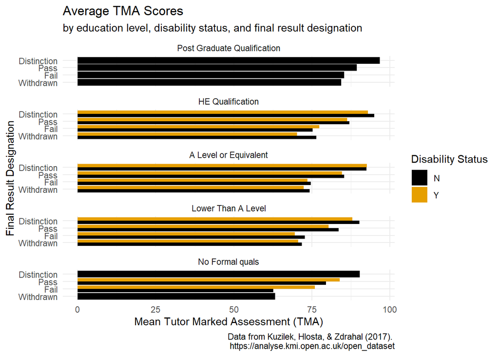